# Отчёт

## Постановка задачи

Мной были выполнены задача Intermidiate. Требовалось:

Уметь классифицировать фигуры на белом фоне

## Описание метода решения

### Бинаризация изображения

Первым действием - бинаризуем изображение. Это необходимо, чтобы выделить какие пиксели отвечают за фигуру, какие за фон. Далее работаем только с бинаризованным изображением. Далее несколько раз применяем операцию дилатации, чтобы 'расширить' области, занимаемые самой фигурой, которые были обрезаны в следсвтии перепада яркости и засветов.

### Определение типа фигуры

1. Нетрудно видеть, что фигуры (1), (2,4), (3) отличаются кол-вом дырок, их соответсвенно 4, 2, 5. Выделяем связные компоненты на бинаризованном изображении и в зависисмости от их количесвта можем определить 1, 3 или одна из (2,4) фигура.
2. Разделять же 2 и 4 фигуры можно по кол-ву пикселей, принадлежащих дыркам. На предоставленных данных было обнаружено, что у фигуры 2 кол-во пикселей, относящихся к дыркам порядка 20000, а у фигуры 4 порядка 40000. Можно привезти некоторые обоснования, что это корректно: в фигуре 2 тяжело сделать площадь дырок больше, из-за конструкции (одну окаямляет 5 звеньев, другую - 6) при любых растягиваниях; в фигуре же 4 нельзя сделать площадь правой дырки, в которой выперает одно звено, так как это звено при сближении с окаймляющими пересечётся с ними и получится другая фигура.

## Описание программной реализации

Алгоритмы реализованы на языке python при использовании множества функций из библиотеки skimage для работы с изображениями. Далее для каждого пункта алгоритмов, описанных выше, будет показано, какие функции использовались

1. binarize() - с помощью threshold_yen (threshold_otsu работает хуже) из skimage преобразует изображение в бинаризованное
2. remove_noize() - применяем 3 раза дилатацию из skimage.morphology
3. get_num_holes() - с помощью skimage.measure.label выделяем связные компоненты и определяем число дырок в фигуре
4. detetct_gigure() - основная функция

Ниже представлены результаты и промежуточные преобразования алгоритма

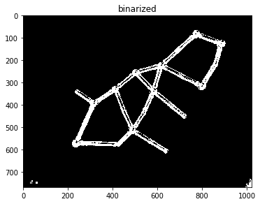

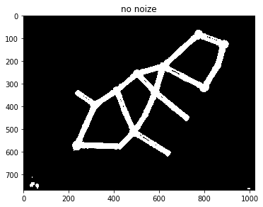

```
Количесвто дырок в фигуре: 4
Количесвто пикселей в дырках фигуры:
[25035  2346 15778 27709]
Ответ: это фигура, номер 1
```

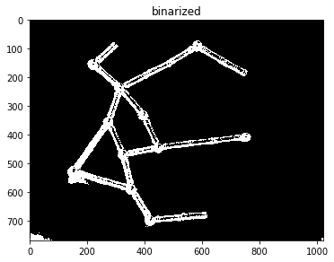

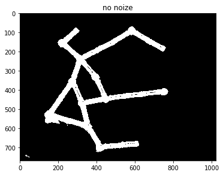

```
Количесвто дырок в фигуре: 2
Количесвто пикселей в дырках фигуры:
[13826 14036]
Ответ: это фигура, номер 2
```

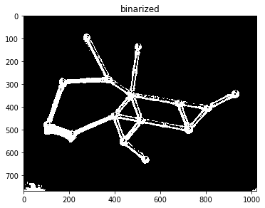

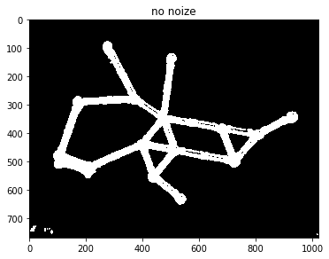

```
Количесвто дырок в фигуре: 5
Количесвто пикселей в дырках фигуры:
[44848 14188  2380  2829  2457]
Ответ: это фигура, номер 3
```

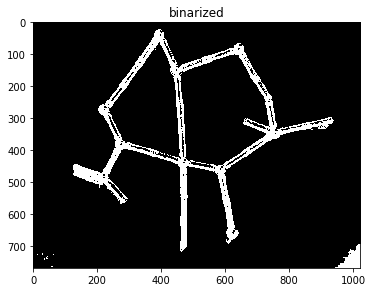

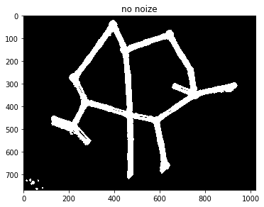

```
Количесвто дырок в фигуре: 2
Количесвто пикселей в дырках фигуры:
[45098 66498]
Ответ: это фигура, номер 4
```

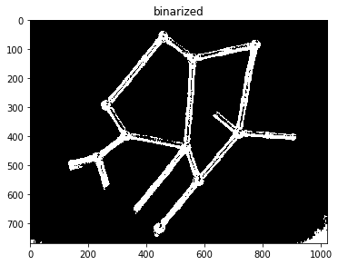

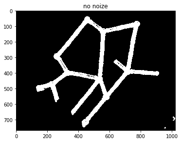

```
Количесвто дырок в фигуре: 2
Количесвто пикселей в дырках фигуры:
[58007 50699]
Ответ: это фигура, номер 4
```

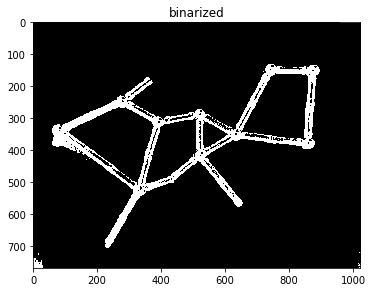

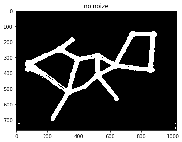

```
Количесвто дырок в фигуре: 4
Количесвто пикселей в дырках фигуры:
[28249 31729 18434  2948]
Ответ: это фигура, номер 1
```

[4 more figures not shown]

```
Количесвто дырок в фигуре: 2
Количесвто пикселей в дырках фигуры:
[20109 20019]
Ответ: это фигура, номер 2
```

```python
for i in [2, 3, 4, 5, 7, 13, 19, 25]:
    img = read_img(str(i)+'.jpg')
    print('Ответ: это фигура, номер', detect_figure(img))
```